# Tutorial 6

12/16/2019- 12/20/2019-

## Overview

- Bootstrapping
- Probability recap
- Models
  - Formal definition
  - Binomial
  - Normal
- Parameters and Priors
- Frequentists vs. Bayesians

## Bootstrapping

- to do sth *by one’s own bootstraps*
  - to do sth by one’s own initiative and effort, with little to no assistance
- in statistics
  - idea: we have limited data at hand and we need to put in our own “effort” to get the most out of the data
  - practice: random **re-samples with replacement**

## Bootstrapping

- specifically for 95% **Confidence Intervals** (e.g. of the mean)
  - vector \(D\) with length \(k\)
  1. take \(k\) samples (**with replacement!**) from \(D\), gather them in a vector \(D^{rep}\)
  2. compute \(\mu(D^{rep})\) and add it to the vector \(\mu_{sampled}\)
  3. repeat 1 and 2
  4. **lower bound** of the 95% CI = **2.5% quantile** of \(\mu_{sampled}\)
  5. **upper bound** of the 95% CI = **97.5% quantile** of \(\mu_{sampled}\)

## Probability Recap

- **marginal**: the prob. of one event happening without considering any other events that might play a role
  - e.g. \(P(heads) = \frac{1}{2}, \ P(spades) = \frac{1}{4}\)
- **joint**: the prob. of many events happening at the same time
  - if *heads* and *spades* are independent: \(P(heads, \ spades) = P(heads) \cdot (spades)\)
- **conditional**: the prob. of an event when you know another event already happened
  - \(P(A \ | \ B) = \frac{P(A, \ B)}{P(B)}\)
  - e.g. \(P(heads) = \frac{1}{2}, \ P(heads \ | \ unfair) = \frac{3}{4}\)

## Bayes’ Rule

- \(P(\theta \ | \ D) = \frac{P(D \ | \ \theta) \cdot P(\theta)}{P(D)}\)
- **rewrite** a certain probability in terms of **other probabilities** that might be much easier to compute
- gain insight into the *unobservable* causes of any given observation
  - for data analysis: starting from the **raw data**, gain insight into the (parameters of the) **underlying distribution** that generated the data at hand

## Bayes’ Rule: Homework Questions

- Medical Test?
- Bertrand Box Paradox?

## Models

- A **statistical model** is a simple and elegant mathematical **representation of a random process**
  - captures the essence of the random process and leaves out all the irrelevant details
- A model \(M\) consists of
  - a dataset \(D\) with **independent variables** \(D_{IV}\) and **dependent variables** \(D_{DV}\)
  - a **likelihood function** \(P_M(D_{DV} \ | \ D_{IV}, \theta)\)
  - the model’s **free parameters** \(\theta\) allow you to fine-tune the model to your specific problem
  - **Bayesian models** additionally have a **prior distribution** \(P_M(\theta)\)

## Likelihood

Likelihood - the likeliness of different parameters of a distribution. In a sence it is a quantitative measure of model fit.

```r
#likelyhood that p==0.5 for a coin which fall head up 2 times out of
#4 tosses
lik1<- dbinom(2, size=4, prob=0.5, log=FALSE)

#likelyhood that p==0.5 for a coin which fall head up 4 times out of
#4 tosses
lik2 <- dbinom(4, size=4, prob=0.5, log=FALSE)
lik1
```

```
## [1] 0.375
```

```r
lik2
```

```
## [1] 0.0625
```

## Likelihood plot

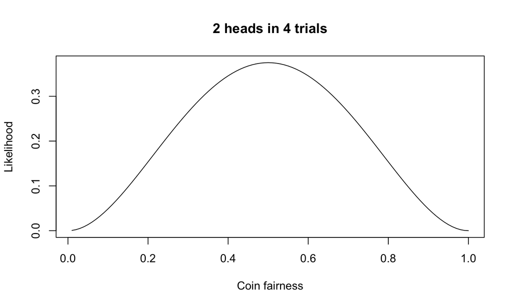

## Likelihood plot

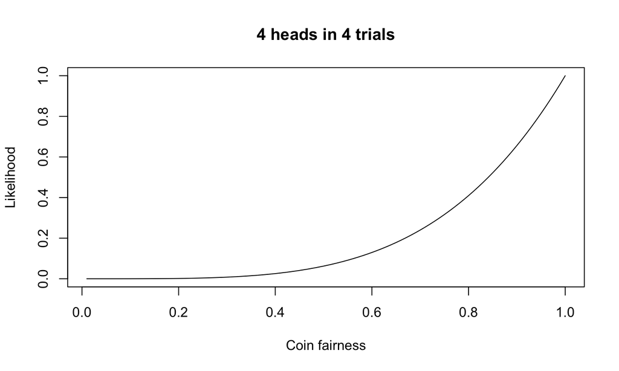

## Log likelihood

Log transformations needed to make working with likelihoods easier! \(\log\prod x_i=log\sum x_i\) Thus, even if you have very small numbers LL does not converge to zero!

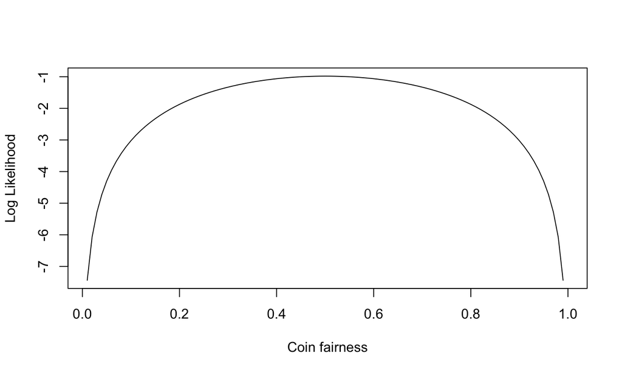

## Models vs Distributions

- What is the difference between a model and a distribution?

## Binomial distribution

- Used to count the number \(k\) of successes out of \(N\) trials in a **binary** random process \[P(A) = \binom{N}{k} \cdot p^k(1-p)^{N-k}\]
- Three assumptions:
  - only **two possible outcomes** (success or failure)
  - probability of success is the **same for each trial**
  - the trials are **independent**

Mean: \(\mu = np\)

Standard Deviation: \(\sigma=\sqrt{n(p)(1-p)}\)

## Binomial distribution: Example

Each day of a month a student learns 10 new words Aprox. 10% would be forgotten

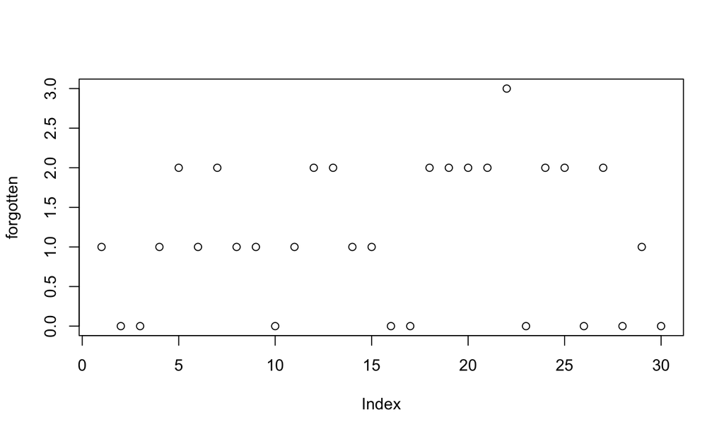

```r
forgotten <- rbinom(30, 10,.10)
plot(forgotten)
```

## Binomial distribution: Parameters

- Mean: \(\mu = np\) and Standard Deviation: \(\sigma=\sqrt{n(p)(1-p)}\)

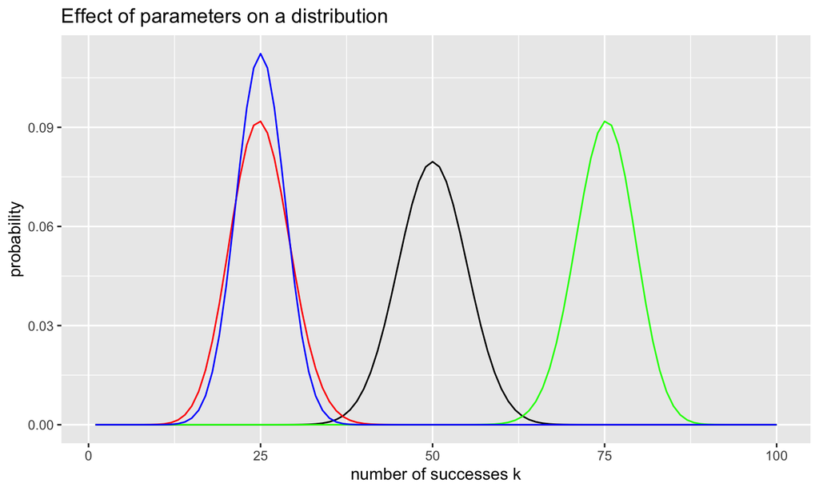

## More on Binomial distribution

```r
dens<- dbinom(30, 300, .1) #probability density distribution
prob <- pbinom(30, 300, .1) #cumulative probability of an event.
quantile<- qbinom(0.54, 300, .1) # takes the probability value and gives
# a number whose cumulative value matches the probability value
round(dens, 3)
```

```
## [1] 0.077
```

```r
round(prob,3)
```

```
## [1] 0.548
```

```r
quantile
```

```
## [1] 30
```

## Normal distribution

Likelihood function:

\[P(x) = \frac{1}{\sigma*\sqrt{2\pi}}e^{\frac{-(x-\mu)^2}{2\sigma^2}} \]

- mean, median and mode of the distribution coincide
- curve of the distribution is symmetrical about the mean.
- total area under the curve is 1 (as for all continuous distributions).

If \(\mu=0\) and \(\sigma=1\) It is called standart normal distribution

## Normal distribution: Example

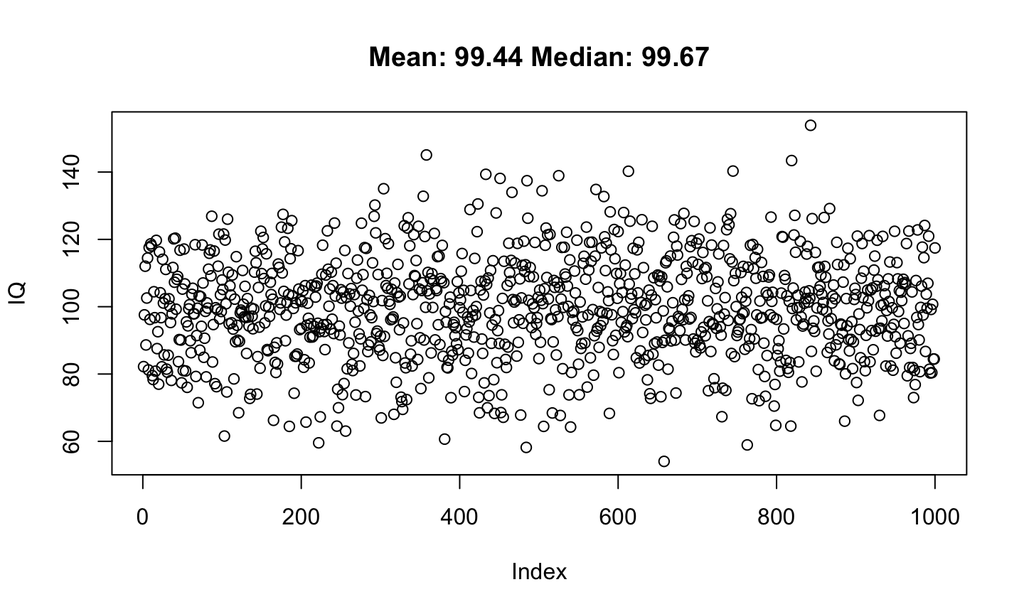

```r
#Imagine we mesure IQ of 1000 people. Then we plot raw data.
IQ <- rnorm(1000, 100, 15)
```

## Normal distribution: Density

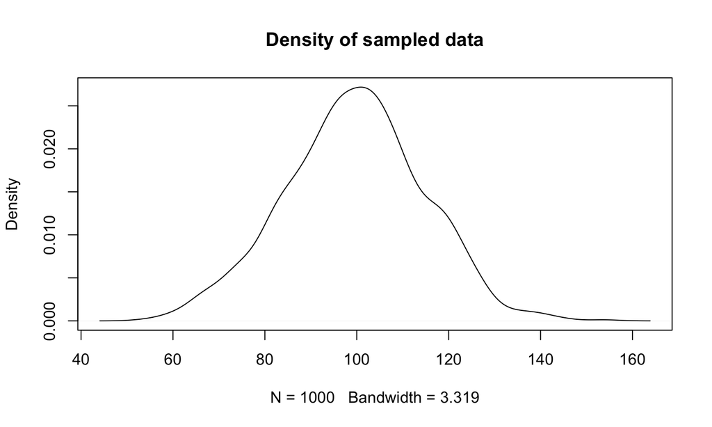

```r
dens <-density(IQ)
plot(dens, main = "Density of sampled data")
```

## Normal distribution: Parameters

- Given the plot below, in which way do the the parameters \(\mu\) (mean) and \(\sigma\) (sd) affect the normal distribution?

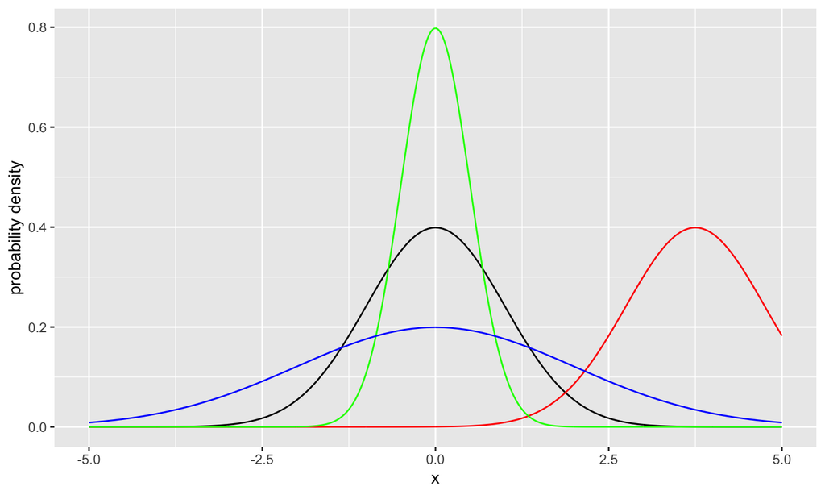

## T-model

- used to compare means of two distrubutions
- both distributions should come from on family (e.g.normal)
- \(\delta\) indicates differencies between the means

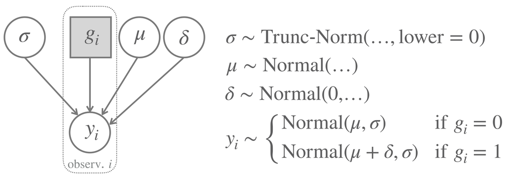

## Which model to use?

```
- if you are intrested how much beer should you buy for a party?

- if you want to check if male height is different among Norh and South Corenians?

- if you want to check whether a new drink increases sense of humor?
```

## Priors

- represent the modeller’s **subjective** *a priori* beliefs about the random process at hand
- may also just be used **pragmatically** to make calculations and statistical reasoning more elegant
- priors **restrict the range of values** any given parameter can take
  - **strongly informative** prior restrict the range a lot
  - **weakly informative** priors restrict the range only a bit
  - **uninformative** priors do not restrict the range, they assume all parameter values are equally likely

## Priors: Exercise

- What types of priors can you identify in the plot below?

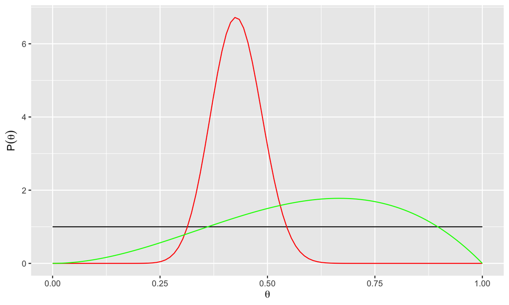

## Priors: example

- For the calculation how much beer should you buy for a party:
  - our very close friends are coming and we know their habits: **strongly informative**
  - our not that close friends are coming and we have a rough idea of their habits: **weakly informative**
  - many strangers are coming, we dont really know their habits: **uninformative prior**s

## Frequentists vs. Bayesians

[figure not shown]